# (LetterBoxd Visualizations And Insights)

by (Hamad Sami AlAssafi)

## Investigation Overview

**This presentation shows the most popular movie genre (based on views & rating), whether the running time affect the average rating or not, whether the people tend to watch old movies or new one, and the movie average rating for some of the most famous directors.**

## What is the most preferable genre by the directors

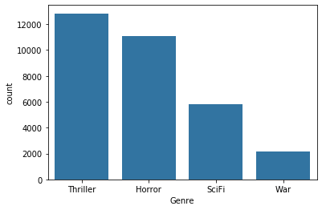

```python
color = sb.color_palette()[0]
List = ['Thriller','Horror','SciFi','War']
sb.countplot(data = df2 , x = 'Genre', color = color, order = List);
```

#### The most preferable genre by the directors is (Thriller) with more than 12000 movie

## What is the most preferable genre by the audience (based on average rating)

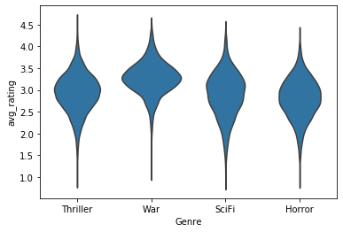

```python
sb.violinplot(data = df2 , x = 'Genre', y = 'avg_rating', color = color , inner = None);
```

#### War genre has the highest average rating, the average rating for War genre is approximately (3.25 out of 5)

## What is the most popular genre (based on average views)

```python
print("Thriller:", round(th1,0))
print("War:     ", round(war1,0))
print("Horror:  ",round(horror1,0))
print("Sci-Fi:  ",round(sci1,0))
```

```
Thriller: 7474.0
War:      5288.0
Horror:   4345.0
Sci-Fi:   12432.0
```

## What are the most common running time for movie (in minutes)

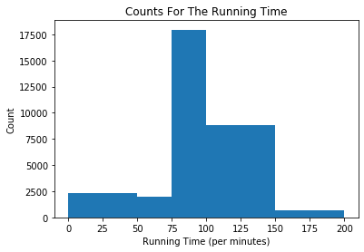

```python
bins = [0,50,75,100,150,200]
plt.hist(data = df2, x = 'running_time', bins = bins);
plt.title('Counts For The Running Time');
plt.xlabel('Running Time (per minutes)');
plt.ylabel('Count');
```

#### more than (17000) movie has running time between (75-100) minute, in hours (1:15-1:40)

## Does the people tend to watch old movies or new one

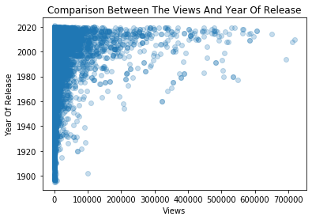

```python
plt.scatter(data = df2 , x = 'views', y = 'year', alpha = 1/4);
plt.title('Comparison Between The Views And Year Of Release');
plt.xlabel('Views');
plt.ylabel('Year Of Release');
```

#### It appears that the number of views has increased for the movies that has been released between (2000-2020), and it looks like the views increases by the years, which can be an indicator that the people become more passionate in movies by the years.

## Does the running time affect the average rating

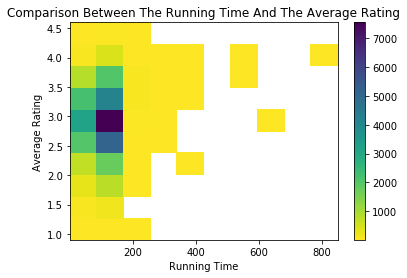

```python
plt.hist2d(data =df2 , x = 'running_time', y = 'avg_rating', cmap = 'viridis_r', cmin = 1);
plt.colorbar();
plt.xlabel('Running Time');
plt.ylabel('Average Rating');
plt.title('Comparison Between The Running Time And The Average Rating');
```

## What are the most common average rating

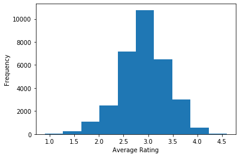

```python
df2.avg_rating.plot(kind = 'hist');
plt.xlabel('Average Rating');
```

#### The most common average rating is between (2.7-3 out of 5)

## What is the most viewed movie in letterboxd

```python
df2.query('views == 719791')
```

|  | title | year | director | running_time | views | likes | avg_rating | half_star | one_star | one_half_star | two_star | two_half_star | three_star | three_half_star | four_star | four_half_star | five_star | Genre |
| --- | --- | --- | --- | --- | --- | --- | --- | --- | --- | --- | --- | --- | --- | --- | --- | --- | --- | --- |
| 5823 | Inception | 2010.0 | Christopher Nolan | 148 | 719791 | 260768 | 4.2 | 650 | 1723 | 1122 | 7176 | 6262 | 36532 | 38146 | 121351 | 64075 | 128253 | SciFi |

#### Inception (2010) Directed by Christopher Nolan with (719791) views

## What is the most liked movie in letterboxd

```python
df2.query('likes == 286934')
```

|  | title | year | director | running_time | views | likes | avg_rating | half_star | one_star | one_half_star | two_star | two_half_star | three_star | three_half_star | four_star | four_half_star | five_star | Genre |
| --- | --- | --- | --- | --- | --- | --- | --- | --- | --- | --- | --- | --- | --- | --- | --- | --- | --- | --- |
| 12833 | Pulp Fiction | 1994.0 | Quentin Tarantino | 154 | 693834 | 286934 | 4.4 | 642 | 1592 | 738 | 4727 | 3552 | 24158 | 24063 | 97896 | 65407 | 181714 | Thriller |

#### Pulp Fiction (1994) Directed by Quentin Tarantino with (286934) likes

## What is the most rated movie in letterboxd

```python
df2.query('avg_rating == 4.6')
```

|  | title | year | director | running_time | views | likes | avg_rating | half_star | one_star | one_half_star | two_star | two_half_star | three_star | three_half_star | four_star | four_half_star | five_star | Genre |
| --- | --- | --- | --- | --- | --- | --- | --- | --- | --- | --- | --- | --- | --- | --- | --- | --- | --- | --- |
| 0 | Parasite | 2019.0 | Bong Joon-ho | 133 | 539266 | 283450 | 4.6 | 308 | 427 | 289 | 1266 | 1640 | 8667 | 14524 | 69003 | 90025 | 243931 | Thriller |

#### Parasite (2019) Directed by Bong Joon-ho with (4.6 out of 5) average rating

## What is the longest movie in letterboxd

```python
df2.query('running_time == 803')
```

|  | title | year | director | running_time | views | likes | avg_rating | half_star | one_star | one_half_star | two_star | two_half_star | three_star | three_half_star | four_star | four_half_star | five_star | Genre |
| --- | --- | --- | --- | --- | --- | --- | --- | --- | --- | --- | --- | --- | --- | --- | --- | --- | --- | --- |
| 11946 | La Flor | 2018.0 | Mariano Llinás | 803 | 2091 | 884 | 4.2 | 6 | 8 | 11 | 42 | 45 | 76 | 140 | 330 | 283 | 504 | Thriller |

#### La Flor (2018) Directed by Mariano Llinás, the running time is (803) minute, 13 hour and 23 minute

## What are the average movies rating for some of the most famous directors

```python
print('The average movies rating for Martin Scorsese is:   ', scor)
print('The average movies rating for Quentin Tarantino is: ', quentin)
print('The average movies rating for Christopher Nolan is: ', chris)
print('The average movies rating for David Fincher is:     ', david)
print('The average movies rating for Stanley Kubrick is:   ', stan)
print('The average movies rating for Billy Wilder is:      ', bill)
```

```
The average movies rating for Martin Scorsese is:    3.66
The average movies rating for Quentin Tarantino is:  4.02
The average movies rating for Christopher Nolan is:  3.87
The average movies rating for David Fincher is:      3.62
The average movies rating for Stanley Kubrick is:    3.97
The average movies rating for Billy Wilder is:       3.7
```

# Thank You :)

# Twitter: @HamadAlAssafi